# Analysis PPM-S

jueves 30 julio 2020 16:11:44

# 1 Wave 01

On the first wave of the study we conducted the application of the Perceptions and Preferences Meritocracy Scale (PPM-S), in which we decided to test three different modalities for the application of the scale. The design of the study considered a sample of 2200 cases in Chile, using quotas for sex, age and educational level. The most important feature of this study consists in that we randomly assigned the participants to three different groups, in which the subjects complete one of the three combination of the questions. The key feature of these combinations relies on the display order of the questions regarding to each indicator of the scale. On this respect, we have three subsamples that correspond to each application modality that can be analysed separately, but also all together as a full sample.

The scale has eight indicators, divided in four questions for perception and four for preferences, which are also divided in meritocratic and non-meritocratic. The meritocratic indicators refers to topics such as effort and talent, and the non-meritocratic refers to family wealth and networks. The three combinations relies in how these indicators are displayed to the respondent. The first combination corresponds to the group that answered the questions that were sorted by the Perceptions/Preferences dimension. the second combination corresponds to the group in which the questions are displayed following the a topic-sorted way, this means that the effort, talent, rich family and networks questions for perception and preference were displayed together. The last and third group corresponds to a completely randomized display order of the questions.

The rationale of the design relies on the possibility to test how different display modalities could affect the hypothesized factor structure of the scale. On this regard, we conducted the analysis on two stages. On the first stage we tested the hypothesized factor structure on the three groups corresponding to each application modality and the full sample using a Confirmatory Factor Analysis (CFA). On the second stage, we conducted a Multi-group confirmatory factor analysis (MGCFA) using the groups created by the randomization. Furthermore, we explore the possibility of a second order factor structure, in which we tested two models. The first alternative corresponds to a second-order Confirmatory Factor Analysis assuming the Perception/Preference dimension as a second order factor. On the other hand, we tested a model in which we assume that the second order factor structure follows the Meritocratic/Non-meritocratic constructs.

**Libraries**

```r
library(sjPlot)
library(dplyr)
library(lavaan)
library(semPlot)
library(stargazer)
library(corrplot)
library(psych)
library(knitr)
library(kableExtra)
library(rvest)
library(sjlabelled)
source('production/prod_polychoric.R')
```

**Load data**

```r
load(file = "input/data/proc/dat01.RData")
load(file = "input/data/proc/dat02.RData")
load(file = "input/data/proc/dat03.RData")
load(file = "input/data/proc/dat04.RData")
```

```r
table_format = if(is_html_output()) {
  "html"
} else if(is_latex_output()) {
  "latex"
}
```

**Modality**

Each group correspond to the application modality of the scale.

1. **Version 01:** Fixed order by perception / preferences (N=712)
2. **Version 02:** Fixed order, by topic (N=717)
3. **Version 03:** Random order (N=712)
4. **Complete Sample:** Complete sample (N=2141)

## 1.1 Version 01 (N=712)

Mode 01: Fixed order by perception

| Spanish (original) | English (translated) |
| --- | --- |
| A. Percepción esfuerzo | Perception effort |
| B. Percepción talento | Perception talent |
| C. Percepción familia rica | Perception rich family |
| D. Percepción redes | Perception networks |
| E. Preferencia esfuerzo | Preference effort |
| F. Preferencia talento | Preference talent |
| G. Preferencia familia rica | Preference rich family |
| H. Preferencia redes | Preference networks |

**Descriptive statistics**

| Statistic | N | Mean | St. Dev. | Min | Pctl(25) | Median | Pctl(75) | Max |
| --- | --- | --- | --- | --- | --- | --- | --- | --- |
| A. pc.effort | 712 | 3.16 | 1.36 | 1 | 2 | 3 | 4 | 5 |
| B. pc.talent | 712 | 2.98 | 1.12 | 1 | 2 | 3 | 4 | 5 |
| C. pc.wpart | 712 | 3.60 | 1.36 | 1 | 3 | 4 | 5 | 5 |
| D. pc.netw | 712 | 3.73 | 1.27 | 1 | 3 | 4 | 5 | 5 |
| E. pf.effort | 712 | 3.91 | 1.22 | 1 | 3 | 4 | 5 | 5 |
| F. pf.talent | 712 | 3.27 | 1.17 | 1 | 3 | 3 | 4 | 5 |
| G. pf.wpart | 712 | 2.55 | 1.12 | 1 | 2 | 3 | 3 | 5 |
| H. pf.netw | 712 | 2.33 | 1.06 | 1 | 1 | 2 | 3 | 5 |

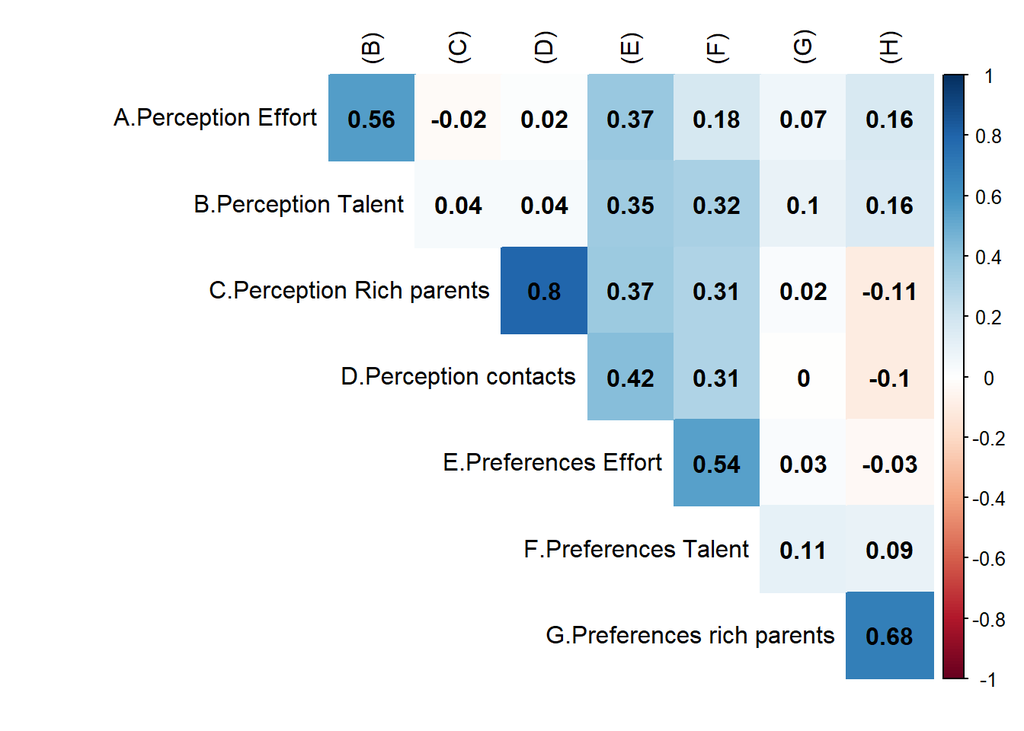

```r
cor01<-polychoric(dat01)
rownames(cor01$rho) <- c("A.Perception Effort", "B.Perception Talent","C.Perception Rich parents","D.Perception contacts","E.Preferences Effort","F.Preferences Talent","G.Preferences rich parents", "H.Preferences contacts" )
colnames(cor01$rho) <- c("(A)","(B)","(C)","(D)","(E)","(F)","(G)", "(H)")


corrplot(cor01$rho,method = "color" ,type = "upper", tl.col = "black", addCoef.col = "black",diag = FALSE)
```

```r
model01 <- 'perc_merit=~perc_effort+perc_talent
            perc_nmerit=~perc_wpart+perc_netw
            pref_merit=~pref_effort+pref_talent
            pref_nmerit=~pref_wpart+pref_netw'

fit1_c <- cfa(model = model01,data = dat01,estimator="MLR") # Continuous/ estimator ML Robust

fit1_o <- cfa(model = model01,data = dat01,
            ordered = c("perc_effort","perc_talent",
                        "perc_wpart","perc_netw",
                        "pref_effort","pref_talent",
                        "pref_wpart","pref_netw"))

#---------------------------------------------------#
cnames <- c("Factor","Indicator","Loading (MLR)","Loading (DWLS)")
kable(left_join(x = standardizedsolution(fit1_c) %>% filter(op=="=~") %>% select(lhs,rhs,est.std),y = standardizedsolution(fit1_o) %>% filter(op=="=~") %>% select(lhs,rhs,est.std),c("lhs","rhs")),
      format = "markdown",digits = 2,col.names = cnames, caption = "Factor loadings")
```

| Factor | Indicator | Loading (MLR) | Loading (DWLS) |
| --- | --- | --- | --- |
| perc_merit | perc_effort | 0.70 | 0.69 |
| perc_merit | perc_talent | 0.72 | 0.81 |
| perc_nmerit | perc_wpart | 0.80 | 0.85 |
| perc_nmerit | perc_netw | 0.92 | 0.94 |
| pref_merit | pref_effort | 0.82 | 0.85 |
| pref_merit | pref_talent | 0.58 | 0.64 |
| pref_nmerit | pref_wpart | 0.46 | 0.55 |
| pref_nmerit | pref_netw | 1.37 | 1.26 |

> **NOTE**: good fit, heywood case item 8.

```r
labs<- c("A. Who the more they try they manage to get bigger rewards that those who striveless.",
         "B. Who possess more talent they manage to obtain greater rewards than those who possess less talent.",
         "C. Who they have rich parents manage to get out ahead.",
         "D. Who they have good contacts they manage to get out ahead.",
         "E. Who the more they try they should get greater rewards than those who they try less." ,
         "F. Who possess more talent they should get greater rewards than those who possess less talent." ,
         "G. It's fine that those who have rich parents get ahead",
         "H. Is well that those who have good contacts get ahead." )
cnametab<- c("","(A)","(B)","(C)","(D)","(E)","(F)","(G)", "(H)","(1)","(2)","(3)","(4)","(1)","(2)","(3)","(4)")
```

```r
#polyw01<- poly(sjlabelled::remove_all_labels(dat01),
#               digits = 2,
#               triangle = "l",
#               fade.ns = F,
#               remove.spaces = T,
#               string.diag = c("$-$","$-$","$-$","$-$","$-$","$-$","$-$","$-$"))
#matpolyw01 <- as.data.frame(read_html(x = polyw01[["page.content"]]) %>% html_table(fill=FALSE))
#matpolyw01 <- matpolyw01[-c(9),]
#colnames(matpolyw01) <- c("vars","(A)","(B)","(C)","(D)","(E)","(F)","(G)","(H)")

#load01<- data.frame(round(cbind(inspect(fit1_c,what="std")$lambda,inspect(fit1_o,what="std")$lambda),digits = 2))
#load01[load01==c(0.00)] <- NA; names(load01) <- c(1:4,1:4)

#table01<- bind_cols(x = matpolyw01,y = load01)
##### %>% mutate(vars=labs)

#kable(table01,escape = TRUE,align = "l",col.names = cnametab,format = "html") %>%
#  footnote(general = paste0(paste0("$N$= ",nobs(fit1_c)),"; p<0.05=$*$; p<0.01=$**$; p<0.001=$***$"),footnote_as_chunk = T) %>%
#  add_header_above(c(" " = 1,"Polychoric correlations"=8, "MLR" = 4, "DWLS" = 4))%>%
#  add_header_above(c(" " = 9,"Factor loadings"=8)) %>%
#  column_spec(column = c(1),width ="7in",include_thead = T) %>%
#  column_spec(column = c(2:17),width ="0.5in",include_thead = T) %>%
#  kable_styling(full_width = FALSE)
```

## 1.2 Version 02 (N=717)

Mode 02: Fixed order, by topic.

| Spanish (original) | English (translated) |
| --- | --- |
| A. Percepción esfuerzo | Perception effort |
| E. Preferencia esfuerzo | Preference effort |
| B. Percepción talento | Perception talent |
| F. Preferencia talento | Preference talent |
| C. Percepción familia rica | Perception rich family |
| G. Preferencia familia rica | Preference rich family |
| D. Percepción redes | Perception networks |
| H. Preferencia redes | Preference networks |

**Descriptive statistics**

| Statistic | N | Mean | St. Dev. | Min | Pctl(25) | Median | Pctl(75) | Max |
| --- | --- | --- | --- | --- | --- | --- | --- | --- |
| A. pc.effort | 717 | 3.10 | 1.40 | 1 | 2 | 3 | 4 | 5 |
| E. pf.effort | 717 | 3.73 | 1.35 | 1 | 3 | 4 | 5 | 5 |
| B. pc.talent | 717 | 3.03 | 1.11 | 1 | 2 | 3 | 4 | 5 |
| F. pf.talent | 717 | 3.13 | 1.16 | 1 | 2 | 3 | 4 | 5 |
| C. pc.wpart | 717 | 3.66 | 1.37 | 1 | 3 | 4 | 5 | 5 |
| G. pf.wpart | 717 | 2.75 | 1.20 | 1 | 2 | 3 | 4 | 5 |
| D. pc.netw | 717 | 3.73 | 1.22 | 1 | 3 | 4 | 5 | 5 |
| H. pc.netw | 717 | 2.39 | 1.11 | 1 | 1 | 2 | 3 | 5 |

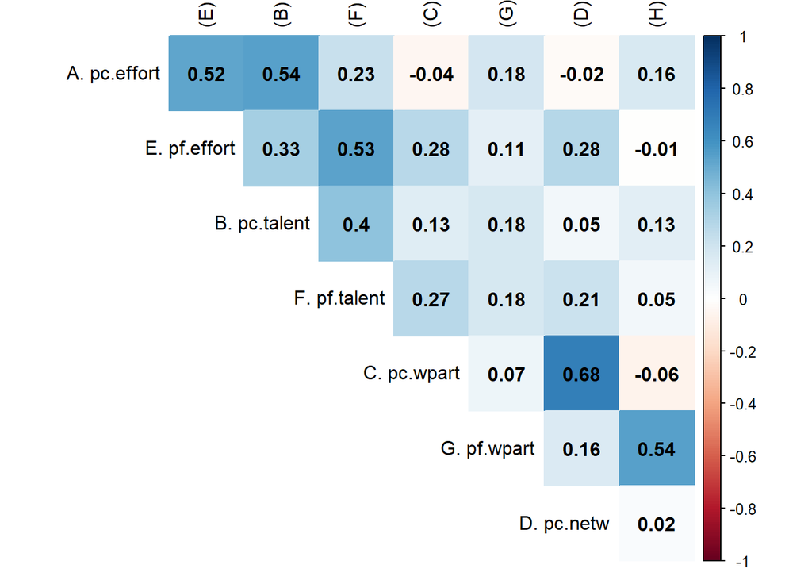

```r
cor02<-polychoric(dat02)
rownames(cor02$rho) <-c("A. pc.effort","E. pf.effort","B. pc.talent","F. pf.talent","C. pc.wpart","G. pf.wpart","D. pc.netw","H. pc.netw")
colnames(cor02$rho) <-c("(A)", "(E)","(B)","(F)","(C)","(G)","(D)", "(H)")
corrplot(cor02$rho,method = "color", type = "upper", tl.col = "black", addCoef.col = "black",diag = FALSE)
```

```r
model02 <- 'perc_merit=~perc_effort+perc_talent
            perc_nmerit=~perc_wpart+perc_netw
            pref_merit=~pref_effort+pref_talent
            pref_nmerit=~pref_wpart+pref_netw'

fit2_c <- cfa(model = model02,data = dat02,estimator="MLR") # Continuous/ estimator ML Robust

fit2_o <- cfa(model = model02,data = dat02,ordered = c("perc_effort","perc_talent",
                                                       "perc_wpart"  ,"perc_netw",
                                                       "pref_effort" ,"pref_talent",
                                                       "pref_wpart"  ,"pref_netw"))

#---------------------------------------------------#
cnames <- c("Factor","Indicator","Loading (MLR)","Loading (DWLS)")
kable(left_join(x = standardizedsolution(fit2_c) %>% filter(op=="=~") %>% select(lhs,rhs,est.std),y = standardizedsolution(fit2_o) %>% filter(op=="=~") %>% select(lhs,rhs,est.std),c("lhs","rhs")),
      format = "markdown",digits = 2,col.names = cnames, caption = "Factor loadings")
```

| Factor | Indicator | Loading (MLR) | Loading (DWLS) |
| --- | --- | --- | --- |
| perc_merit | perc_effort | 0.82 | 0.76 |
| perc_merit | perc_talent | 0.59 | 0.72 |
| perc_nmerit | perc_wpart | 0.74 | 0.84 |
| perc_nmerit | perc_netw | 0.80 | 0.81 |
| pref_merit | pref_effort | 0.83 | 0.82 |
| pref_merit | pref_talent | 0.54 | 0.65 |
| pref_nmerit | pref_wpart | 0.88 | 1.04 |
| pref_nmerit | pref_netw | 0.55 | 0.52 |

> **NOTE**: bad fit, heywood case using DWLS

## 1.3 Version 03 (N=712)

Mode 03: Randomized order.

| Spanish (original) | English (translated) |
| --- | --- |
| Orden aleatorio | Randomized order |

**Descriptive statistics**

| Statistic | N | Mean | St. Dev. | Min | Pctl(25) | Median | Pctl(75) | Max |
| --- | --- | --- | --- | --- | --- | --- | --- | --- |
| A. pc.effort | 712 | 3.33 | 1.37 | 1 | 2 | 4 | 5 | 5 |
| B. pc.talent | 712 | 3.07 | 1.25 | 1 | 2 | 3 | 4 | 5 |
| C. pc.wpart | 712 | 3.72 | 1.36 | 1 | 3 | 4 | 5 | 5 |
| D. pc.netw | 712 | 3.90 | 1.24 | 1 | 3 | 4 | 5 | 5 |
| E. pf.effort | 712 | 4.04 | 1.16 | 1 | 4 | 4 | 5 | 5 |
| F. pf.talent | 712 | 3.33 | 1.23 | 1 | 2 | 3 | 4 | 5 |
| G. pf.wpart | 712 | 2.77 | 1.19 | 1 | 2 | 3 | 4 | 5 |
| H. pf.netw | 712 | 2.50 | 1.14 | 1 | 2 | 2 | 3 | 5 |

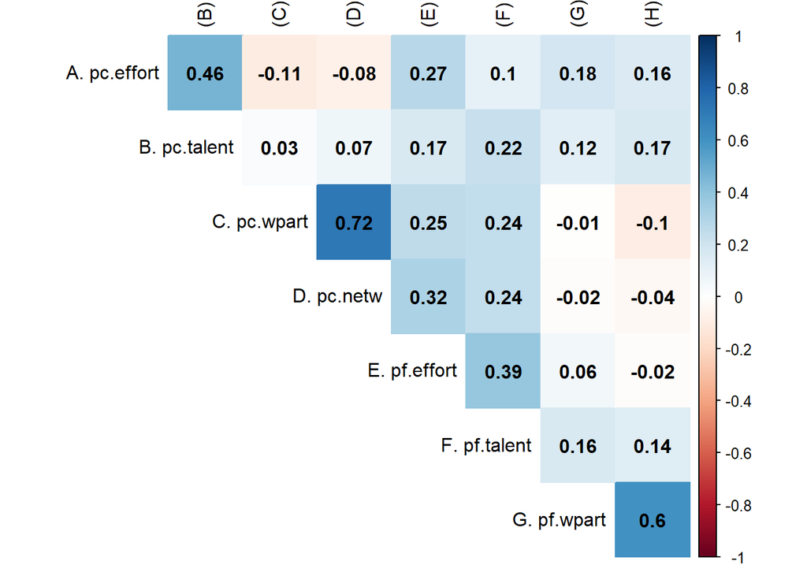

```r
cor03<-polychoric(dat03)
rownames(cor03$rho) <-c("A. pc.effort", "B. pc.talent","C. pc.wpart","D. pc.netw","E. pf.effort","F. pf.talent","G. pf.wpart", "H. pf.netw")
colnames(cor03$rho) <-c("(A)","(B)","(C)","(D)","(E)","(F)","(G)", "(H)")
corrplot(cor03$rho,method = "color", type = "upper", tl.col = "black", addCoef.col = "black",diag = FALSE)
```

```r
model03 <- '
perc_merit=~perc_effort+perc_talent
perc_nmerit=~perc_wpart+perc_netw
pref_merit=~pref_effort+pref_talent
pref_nmerit=~pref_wpart+pref_netw'

fit3_c <- cfa(model = model03,data = dat03,estimator="MLR",std.lv=FALSE) # Continuous/ estimator ML Robust

fit3_o <- cfa(model = model03,data = dat03,ordered = c("perc_effort","perc_talent",
                                                       "perc_wpart","perc_netw",
                                                       "pref_effort","pref_talent",
                                                       "pref_wpart","pref_netw"),std.lv=FALSE)
#---------------------------------------------------#
cnames <- c("Factor","Indicator","Loading (MLR)","Loading (DWLS)")
kable(left_join(x = standardizedsolution(fit3_c) %>% filter(op=="=~") %>% select(lhs,rhs,est.std),y = standardizedsolution(fit3_o) %>% filter(op=="=~") %>% select(lhs,rhs,est.std),c("lhs","rhs")),
      format = "markdown",digits = 2,col.names = cnames, caption = "Factor loadings")
```

| Factor | Indicator | Loading (MLR) | Loading (DWLS) |
| --- | --- | --- | --- |
| perc_merit | perc_effort | 0.73 | 0.70 |
| perc_merit | perc_talent | 0.56 | 0.65 |
| perc_nmerit | perc_wpart | 0.76 | 0.81 |
| perc_nmerit | perc_netw | 0.80 | 0.89 |
| pref_merit | pref_effort | 0.57 | 0.66 |
| pref_merit | pref_talent | 0.54 | 0.59 |
| pref_nmerit | pref_wpart | 0.76 | 0.78 |
| pref_nmerit | pref_netw | 0.71 | 0.77 |

> **NOTE**: fit not very goood (RMSEA .7), no heywood. Try tau-equivalence

```r
#polyw03<- poly(sjlabelled::remove_all_labels(dat03),
#               digits = 2,
#               triangle = "l",
#               fade.ns = F,
#               remove.spaces = T,
#               string.diag = c("$-$","$-$","$-$","$-$","$-$","$-$","$-$","$-$"))
#matpolyw03 <- as.data.frame(read_html(x = polyw03[["page.content"]]) %>% html_table(fill=FALSE))
#matpolyw03 <- matpolyw03[-c(9),]

#colnames(matpolyw03) <- c("vars","(A)","(B)","(C)","(D)","(E)","(F)","(G)", "(H)")

#load03<- data.frame(round(cbind(inspect(fit3_c,what="std")$lambda,inspect(fit3_o,what="std")$lambda),digits = 2))
#load03[load03==c(0.00)] <- NA; names(load03) <- c(1:4,1:4)

#table03<- bind_cols(x = matpolyw03,y = load03)
   ## %>% mutate(vars=labs)

#kable(table03,escape = FALSE,align = "l",col.names = cnametab) %>%
#  footnote(general = paste0(paste0("$N$= ",nobs(fit3_c)),"; p<0.05=$*$; p<0.01=$**$; p<0.001=$***$"),footnote_as_chunk = T) %>%
#  add_header_above(c(" " = 1,"Polychoric correlations"=8, "MLR" = 4, "DWLS" = 4))%>%
#  add_header_above(c(" " = 9,"Factor loadings"=8)) %>%
#  column_spec(column = c(1),width ="7in",include_thead = T) %>%
#  column_spec(column = c(2:17),width ="0.5in",include_thead = T) %>%
#  kable_styling(full_width = F)
```

### 1.3.1 Tau-equivalence

```r
model03.tau <- '
perc_merit=~ r1*perc_effort+r1*perc_talent
perc_nmerit=~r2*perc_wpart+ r2*perc_netw
pref_merit=~ r3*pref_effort+r3*pref_talent
pref_nmerit=~r4*pref_wpart+ r4*pref_netw'

fit3_c.tau <- cfa(model = model03.tau,data = dat03,estimator="MLR",std.lv=FALSE) # Continuous/ estimator ML Robust

fit3_o.tau <- cfa(model = model03.tau,data = dat03,ordered = c("perc_effort","perc_talent",
                                                               "perc_wpart","perc_netw",
                                                               "pref_effort","pref_talent",
                                                               "pref_wpart","pref_netw"), std.lv=FALSE)
#---------------------------------------------------#
cnames <- c("Factor","Indicator","Loading (MLR)","Loading (DWLS)")
kable(left_join(x = standardizedsolution(fit3_c.tau ) %>% filter(op=="=~") %>% select(lhs,rhs,est.std),y = standardizedsolution(fit3_o.tau) %>% filter(op=="=~") %>% select(lhs,rhs,est.std),c("lhs","rhs")),
      format = "markdown",digits = 2,col.names = cnames)
```

| Factor | Indicator | Loading (MLR) | Loading (DWLS) |
| --- | --- | --- | --- |
| perc_merit | perc_effort | 0.61 | 0.68 |
| perc_merit | perc_talent | 0.66 | 0.68 |
| perc_nmerit | perc_wpart | 0.75 | 0.85 |
| perc_nmerit | perc_netw | 0.82 | 0.85 |
| pref_merit | pref_effort | 0.57 | 0.62 |
| pref_merit | pref_talent | 0.54 | 0.62 |
| pref_nmerit | pref_wpart | 0.72 | 0.78 |
| pref_nmerit | pref_netw | 0.75 | 0.78 |

```r
kable(rbind(Ordinal    =fitmeasures(fit3_o    )[c("chisq.scaled","df","cfi","cfi.scaled","cfi.robust","rmsea","rmsea.scaled","rmsea.robust")],
            Ordinal.tau=fitmeasures(fit3_o.tau)[c("chisq.scaled","df","cfi","cfi.scaled","cfi.robust","rmsea","rmsea.scaled","rmsea.robust")]),
      format = "markdown",
      digits = 3, caption = "Fit tau-equivalence")
```

|  | chisq.scaled | df | cfi | cfi.scaled | cfi.robust | rmsea | rmsea.scaled | rmsea.robust |
| --- | --- | --- | --- | --- | --- | --- | --- | --- |
| Ordinal | 63.336 | 14 | 0.991 | 0.979 |  | 0.053 | 0.070 |  |
| Ordinal.tau | 61.430 | 18 | 0.992 | 0.981 |  | 0.044 | 0.058 |  |

```r
kable(anova(fit3_o,fit3_o.tau),
      format = "markdown",
      digits = 3)
```

|  | Df | AIC | BIC | Chisq | Chisq diff | Df diff | Pr(>Chisq) |
| --- | --- | --- | --- | --- | --- | --- | --- |
| fit3_o | 14 |  |  | 41.633 |  |  |  |
| fit3_o.tau | 18 |  |  | 43.152 | 1.945 | 4 | 0.746 |

> **NOTE:** The model with equal factor loadings (in Meritocracy Perception) does not significantly deteriorate the model fit.

## 1.4 Complete sample (N=2141)

Mode 04: Complete sample

| Spanish (original) | English (translated) |
| --- | --- |
| Orden fijo, según percepción/preferencia | Fixed order, by perception/preference |
| Orden fijo, por tópico | Fixed order, by topic. |
| Orden aleatorizado | Randomized order |

**Descriptive statistics**

| Statistic | N | Mean | St. Dev. | Min | Pctl(25) | Median | Pctl(75) | Max |
| --- | --- | --- | --- | --- | --- | --- | --- | --- |
| A. pc.effort | 2141 | 3.20 | 1.38 | 1 | 2 | 3 | 4 | 5 |
| B. pc.talent | 2141 | 3.02 | 1.16 | 1 | 2 | 3 | 4 | 5 |
| C. pc.wpart | 2141 | 3.66 | 1.36 | 1 | 3 | 4 | 5 | 5 |
| D. pc.netw | 2141 | 3.79 | 1.24 | 1 | 3 | 4 | 5 | 5 |
| E. pf.effort | 2141 | 3.89 | 1.25 | 1 | 3 | 4 | 5 | 5 |
| F. pf.talent | 2141 | 3.24 | 1.19 | 1 | 2 | 3 | 4 | 5 |
| G. pf.wpart | 2141 | 2.69 | 1.18 | 1 | 2 | 3 | 4 | 5 |
| H. pf.netw | 2141 | 2.41 | 1.11 | 1 | 2 | 2 | 3 | 5 |

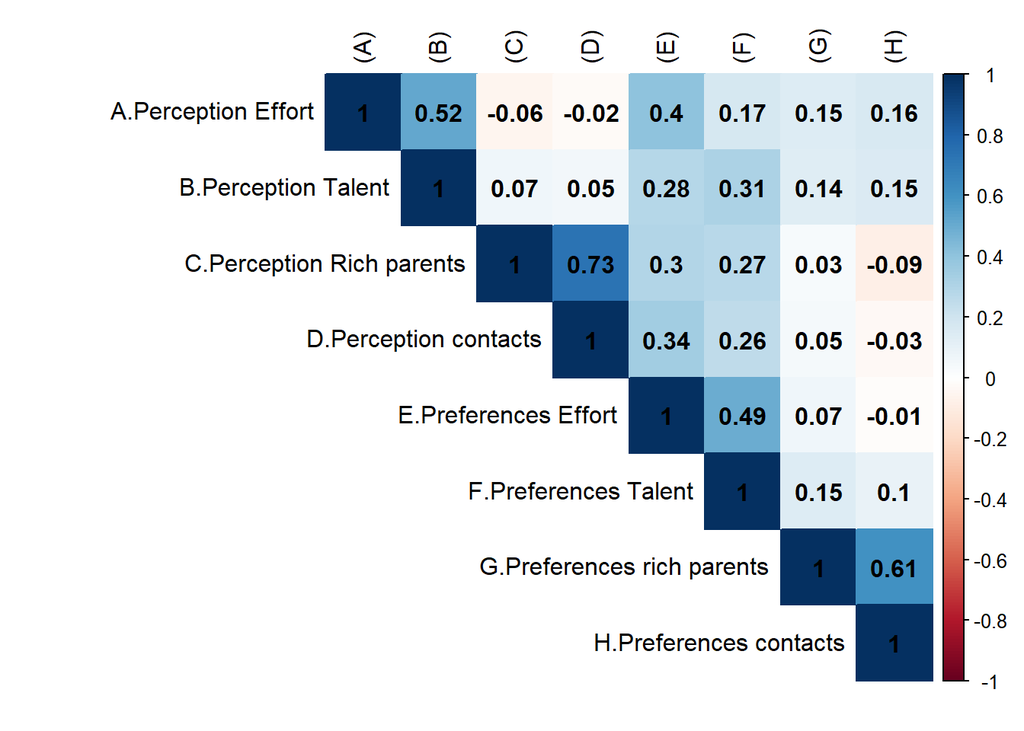

```r
cor04<-polychoric(select(dat04,perc_effort,perc_talent,perc_wpart,perc_netw,pref_effort,pref_talent,pref_wpart,pref_netw))
rownames(cor04$rho) <-c("A.Perception Effort", "B.Perception Talent","C.Perception Rich parents","D.Perception contacts","E.Preferences Effort","F.Preferences Talent","G.Preferences rich parents", "H.Preferences contacts" )
colnames(cor04$rho) <-c("(A)", "(B)","(C)","(D)","(E)","(F)","(G)", "(H)")
save(cor04, file = "output/images/correlation.RData")
corrplot(cor04$rho,method = "color", type = "upper", tl.col = "black", addCoef.col = "black",diag = TRUE)
```

```r
png("output/images/corpoly.png",
    width = 15,height = 15,units="cm",
    pointsize=12,bg="white",res=300)

corrplot(cor01$rho,method = "color" ,type = "upper", tl.col = "black", addCoef.col = "black",diag = TRUE)

dev.off()
```

```r
model04 <- '
perc_merit =~ perc_effort+perc_talent
perc_nmerit=~perc_wpart +perc_netw
pref_merit =~ pref_effort+pref_talent
pref_nmerit=~pref_wpart +pref_netw'

fit4_c <- cfa(model = model04,data = dat04,estimator="MLR",std.lv=FALSE) # Continuous/ estimator ML Robust

fit4_o <- cfa(model = model04,data = dat04,ordered = c("perc_effort","perc_talent",
                                                       "perc_wpart","perc_netw",
                                                       "pref_effort","pref_talent",
                                                       "pref_wpart","pref_netw"),std.lv=FALSE)
#---------------------------------------------------#
cnames <- c("Factor","Indicator","Loading (MLR)","Loading (DWLS)")
kable(left_join(x = standardizedsolution(fit4_c ) %>% filter(op=="=~") %>% select(lhs,rhs,est.std),y = standardizedsolution(fit4_o) %>% filter(op=="=~") %>% select(lhs,rhs,est.std),c("lhs","rhs")),
      format = "markdown",digits = 2,col.names = cnames, caption = "Factor loadings")
```

| Factor | Indicator | Loading (MLR) | Loading (DWLS) |
| --- | --- | --- | --- |
| perc_merit | perc_effort | 0.75 | 0.72 |
| perc_merit | perc_talent | 0.62 | 0.72 |
| perc_nmerit | perc_wpart | 0.77 | 0.83 |
| perc_nmerit | perc_netw | 0.85 | 0.88 |
| pref_merit | pref_effort | 0.76 | 0.78 |
| pref_merit | pref_talent | 0.55 | 0.63 |
| pref_nmerit | pref_wpart | 0.71 | 0.80 |
| pref_nmerit | pref_netw | 0.77 | 0.76 |

```r
nodeNames <-c("Perception effort","Perception talent","Perception rich family","Perception contacts",
              "Preference effort","Preference talent","Preference rich family","Preference contacts",
              "Perception meritocratic","Perception non meritocratic","Preference meritocratic","Preference non meritocratic")

semPaths(fit4_o ,
whatLabels = "std",
what="col",
label.cex=1,
edge.label.cex=1,
residuals=F,
edge.color = "black",
style = "lisrel",
fade=F,
nCharNodes = 0,
 curvePivot = FALSE,
         curve = 2,
rotation = 4,
layout = "tree3",
         cardinal = "lat cov",
legend.cex = 0.6,
         label.cex =1,
label.font = 6,
         edge.label.font= 1,
         asize = 3,
edge.width =1,
         sizeMan=5,
         sizeLat = 10, width = 12,
         height= 15, nodeNames = nodeNames, intercepts = F, reorder = F, thresholds = F, nodeLabels = c("A","B","C","D","E","F","G","H","1","2","3","4"), filetype ="png", filename = "output/images/meas01") #arrow size)
```

# 2 Tables

```r
#load04<- data.frame(round(inspect(fit4_o,what="std")$lambda,digits = 2))
#load04[load04==c(0.00)] <- NA; names(load04) <- c(1:4)

#colnames(matpolyw04) <- c("Variable","A","B","C","D","E","F","G", "H")

#sum04b  <- psych::describe(dat04[,-c(1)], fast = T) %>% select(mean,sd,min,max) %>% data.frame() %>% round(digits = 2)
#table04b<- bind_cols(x = sum04b,y = matpolyw04) %>% select(Variable, everything()) %>% mutate(Variable=labs) %>% rename("Mean"=mean, "SD"=sd, "Min"=min,"Max"=max)

#cap01 <- "Descriptive statistic"
#sumdat04<- kable(table04b, escape = FALSE,align = "l",linesep = "", caption = cap01) %>%
#           column_spec(column = 1,width = "10cm",width_min = "12cm",include_thead = TRUE) %>%
#           footnote(general = paste0(paste0("$N$= ","2141"),"; p<0.05=$*$; p<0.01=$**$; p<0.001=$***$"),footnote_as_chunk = T) %>%
#           add_header_above(header = c(" "=5,"Polychoric correlations"= 8)) %>%
#           kable_styling(full_width = TRUE,font_size = 8,position = "center");sumdat04
#save(sumdat04,file = "output/tables/sumdat04.RData")
```

```r
tb.load<- data.frame(round(cbind(inspect(fit1_o,what="std")$lambda,
                                 inspect(fit2_o,what="std")$lambda,
                                 inspect(fit3_o,what="std")$lambda),
                           digits = 2))
tb.load[tb.load==c(0.00)] <- NA; names(tb.load) <- c(paste0("M1.",1:4),paste0("M2.",1:4),paste0("M3.",1:4))

for (i in names(tb.load)) {
  # tb.load[,i] <- sjlabelled::as_character(tb.load[,i])
  tb.load[,i] <- sprintf(tb.load[,i], fmt = '%#.2f')
}
tb.load[tb.load=="NA"] <- ""

#-------#
fm01<- data.frame(t(data.frame(fitmeasures(fit1_o, output ="matrix")[c("chisq.scaled","df","cfi.scaled","rmsea.scaled"),]))); row.names(fm01) ="M1.1"
fm02<- data.frame(t(data.frame(fitmeasures(fit2_o, output ="matrix")[c("chisq.scaled","df","cfi.scaled","rmsea.scaled"),]))); row.names(fm02) ="M2.1"
fm03<- data.frame(t(data.frame(fitmeasures(fit3_o, output ="matrix")[c("chisq.scaled","df","cfi.scaled","rmsea.scaled"),]))); row.names(fm03) ="M3.1"

#------chi2, df------#
fm04<- round(rbind(fm01,fm02,fm03),3)
fm04.1 <- fm04 %>% select(chisq.scaled,df)
fm04.1$chisq.scaled <- round(x = fm04.1$chisq.scaled,digits = 1)
fm04.1$df <- round(x = fm04.1$df,digits = 0)
fm04.1$chi2df <- paste0(fm04.1$chisq.scaled,"(",fm04.1$df,")")
fm04.1 <- select(fm04.1,"chi2df")
for (i in names(fm04.1)) {
  fm04.1[,i] <- as.character(fm04.1[,i])
}

#------CFI, RMSEA------#
fm04.2 <- fm04 %>% select(cfi.scaled,rmsea.scaled)
for (i in names(fm04.2)) {
  fm04.2[,i] <- sprintf(fm04.2[,i], fmt = '%#.3f')
}

fm.df      <- bind_cols(fm04.1,fm04.2)
fm.df$nobs <- c(nobs(fit1_o),nobs(fit2_o),nobs(fit3_o))
fm.df <- data.frame(t(fm.df)); colnames(fm.df) <- c("M1.2","M2.2","M3.2")


#------ merge ------#
tb.fm<- bind_rows(tb.load,fm.df)
tb.fm<- tb.fm %>% mutate(vars=c(labs,"$\\chi^2\\text{(df)}$","$\\text{CFI}$","$\\text{RMSEA}$","$N$")) %>% select(vars,everything())
#--table---#
tb.col  <- c("Variables",1:4,1:4,1:4)
tb.foot <- paste0("; p<0.05=$*$; p<0.01=$**$; p<0.001=$***$. Standardised factor loadings using DWLS estimator. CFI = Comparative fit index (scaled), RMSEA = Root mean square error of approximation (scaled)")
tb.caption <- "Factor loadings and fit measures"

tb.fm01<- kable(tb.fm,escape = FALSE,align = "lcccccccccccc",col.names = tb.col, caption = tb.caption) %>%
          kable_styling(full_width = F,font_size = 9) %>%
          column_spec(column = 1,width = "10cm",width_min = "12cm",include_thead = TRUE) %>%
          column_spec(column = 2:13,width = "1cm",width_min = "1.3cm",include_thead = TRUE) %>%
          add_header_above(header = c(" "=1,"Version 1"= 4,"Version 2"= 4,"Version 3"= 4)) %>%
          add_header_above(header = c(" "=1,"Factor loadings"= 12)) %>%
          row_spec(row = 8,hline_after = TRUE) %>%
          add_indent(c(9:12)) %>%
          footnote(general =tb.foot ,footnote_as_chunk = T);tb.fm01
```

(#tab:tb_loads-fitm)Factor loadings and fit measures

| Variables | Factor loadings Version 1 1 | Factor loadings Version 1 2 | Factor loadings Version 1 3 | Factor loadings Version 1 4 | Factor loadings Version 2 1 | Factor loadings Version 2 2 | Factor loadings Version 2 3 | Factor loadings Version 2 4 | Factor loadings Version 3 1 | Factor loadings Version 3 2 | Factor loadings Version 3 3 | Factor loadings Version 3 4 |
| --- | --- | --- | --- | --- | --- | --- | --- | --- | --- | --- | --- | --- |
| A. Who the more they try they manage to get bigger rewards that those who striveless. | 0.69 |  |  |  | 0.76 |  |  |  | 0.70 |  |  |  |
| B. Who possess more talent they manage to obtain greater rewards than those who possess less talent. | 0.81 |  |  |  | 0.72 |  |  |  | 0.65 |  |  |  |
| C. Who they have rich parents manage to get out ahead. |  | 0.85 |  |  |  | 0.84 |  |  |  | 0.81 |  |  |
| D. Who they have good contacts they manage to get out ahead. |  | 0.94 |  |  |  | 0.81 |  |  |  | 0.89 |  |  |
| E. Who the more they try they should get greater rewards than those who they try less. |  |  | 0.85 |  |  |  | 0.82 |  |  |  | 0.66 |  |
| F. Who possess more talent they should get greater rewards than those who possess less talent. |  |  | 0.64 |  |  |  | 0.65 |  |  |  | 0.59 |  |
| G. It’s fine that those who have rich parents get ahead |  |  |  | 0.55 |  |  |  | 1.04 |  |  |  | 0.78 |
| H. Is well that those who have good contacts get ahead. |  |  |  | 1.26 |  |  |  | 0.52 |  |  |  | 0.77 |
| $\chi^2\text{(df)}$ |  | 42.3(14) |  |  |  | 107.6(14) |  |  |  | 63.3(14) |  |  |
| $\text{CFI}$ |  | 0.993 |  |  |  | 0.961 |  |  |  | 0.979 |  |  |
| $\text{RMSEA}$ |  | 0.053 |  |  |  | 0.097 |  |  |  | 0.070 |  |  |
| $N$ |  | 712 |  |  |  | 717 |  |  |  | 712 |  |  |

Note: ; p<0.05=$*$; p<0.01=$**$; p<0.001=$***$. Standardised factor loadings using DWLS estimator. CFI = Comparative fit index (scaled), RMSEA = Root mean square error of approximation (scaled)

```r
save(tb.fm01,file = "output/tables/tb.fm01.RData")


save(tb.fm,file = "output/tables/tb.fm.RData")
save(fm.df,file = "output/tables/fm.df.RData")
save(tb.load,file = "output/tables/tb.load.RData")
```

# 3 Summary

## 3.1 Correlations plots

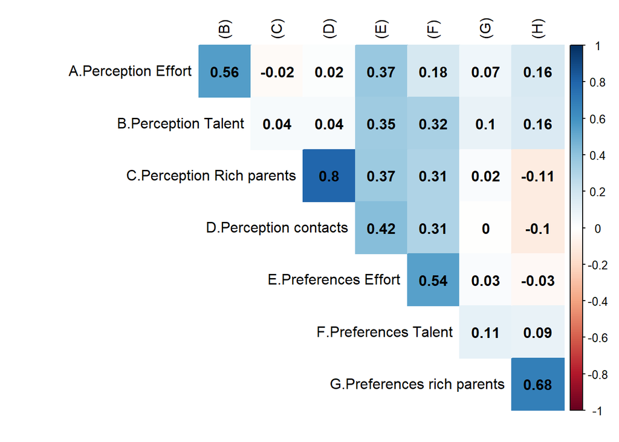

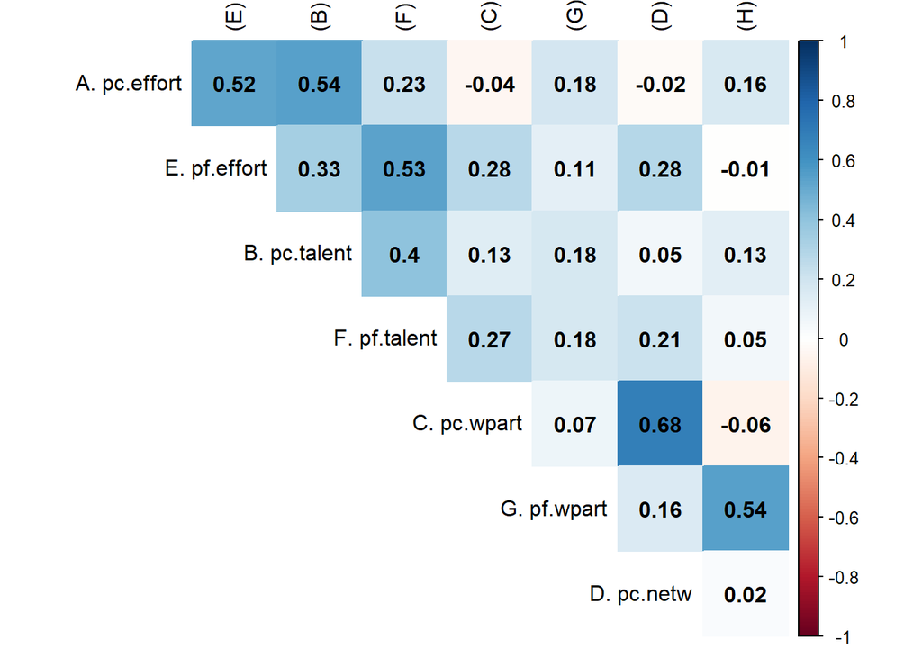

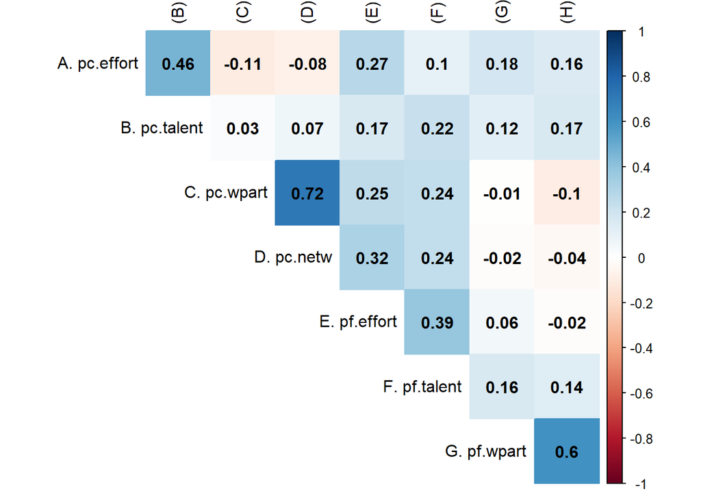

(#fig:compare corr)Mode 01, 02 and 03

```r
corrplot(cor01$rho,method = "color" ,type = "upper", tl.col = "black", addCoef.col = "black",diag = FALSE)
corrplot(cor02$rho,method = "color", type = "upper", tl.col = "black", addCoef.col = "black",diag = FALSE)
corrplot(cor03$rho,method = "color", type = "upper", tl.col = "black", addCoef.col = "black",diag = FALSE)
```

## 3.2 Measurement model

[figure not shown]

```r
model01 <- 'perc_merit=~perc_effort+perc_talent
            perc_nmerit=~perc_wpart+perc_netw
            pref_merit=~pref_effort+pref_talent
            pref_nmerit=~pref_wpart+pref_netw'

plot01 <- cfa(model = model01,data = dat01,estimator="MLR",std.lv=TRUE)

nodeNames <-c("Perception effort","Perception talent","Perception rich family","Perception contacts",
              "Preference effort","Preference talent","Preference rich family","Preference contacts",
              "Perception meritocratic","Perception non meritocratic","Preference meritocratic","Preference non meritocratic")

dir.create("output/images")
semPaths(plot01,
         style = "lisrel",
         fade=FALSE,
         edge.color = "black",
         nCharNodes = 0,
         curvePivot = FALSE,
         curve = 2,
         rotation = 4,
         layout = "tree3",
         cardinal = "lat cov",
         legend.cex = 0.6,
         label.cex =1,
         reorder = FALSE,
         nodeNames = nodeNames,
         nodeLabels = c("A","B","C","D","E","F","G","H","1","2","3","4"),
         label.font = 6,
         edge.label.font= 1,
         asize = 3, #arrow size
         edge.width =1,
         sizeMan=5,
         sizeLat = 10,
         filetype ="png",
         width = 12,
         height= 10,
         filename = "output/images/meas01")
```

## 3.3 Fit indices wave 01

```r
sum_fit<- bind_rows(fitmeasures(fit1_c)[c("chisq.scaled","df","cfi","cfi.scaled","cfi.robust","rmsea","rmsea.scaled","rmsea.robust")],
                    fitmeasures(fit1_o)[c("chisq.scaled","df","cfi","cfi.scaled","cfi.robust","rmsea","rmsea.scaled","rmsea.robust")],
                    fitmeasures(fit2_c)[c("chisq.scaled","df","cfi","cfi.scaled","cfi.robust","rmsea","rmsea.scaled","rmsea.robust")],
                    fitmeasures(fit2_o)[c("chisq.scaled","df","cfi","cfi.scaled","cfi.robust","rmsea","rmsea.scaled","rmsea.robust")],
                    fitmeasures(fit3_c)[c("chisq.scaled","df","cfi","cfi.scaled","cfi.robust","rmsea","rmsea.scaled","rmsea.robust")],
                    fitmeasures(fit3_o)[c("chisq.scaled","df","cfi","cfi.scaled","cfi.robust","rmsea","rmsea.scaled","rmsea.robust")],
                    fitmeasures(fit4_c)[c("chisq.scaled","df","cfi","cfi.scaled","cfi.robust","rmsea","rmsea.scaled","rmsea.robust")],
                    fitmeasures(fit4_o)[c("chisq.scaled","df","cfi","cfi.scaled","cfi.robust","rmsea","rmsea.scaled","rmsea.robust")])
sum_fit$mod <- c("Model 1","Model 1","Model 2","Model 2","Model 3","Model 3","Model 4","Model 4")
sum_fit$est <- c("MLR","DWLS","MLR","DWLS","MLR","DWLS","MLR","DWLS")
sum_fit <- select(sum_fit,mod,est,everything())
colnames <- c("Model","Estimator","$\\chi^2$","df","CFI","CFI.sca","CFI.rob","RMSEA","RMSEA.sca","RMSEA.rob")


sumtable01<- kable(sum_fit,digits = 3,format = "html",row.names = F,booktabs=T, caption = "Summary fit indices wave 01",col.names = colnames,escape = FALSE) %>%
  kable_styling(full_width = F)  %>%
      collapse_rows(columns = 1,valign = "middle")  %>%
      footnote(number = c("Model 1: fixed order by percepction/preference",
                          "Model 2: fixed order by topic (i.e: effort)",
                          "Model 3: Randomized order",
                          "Model 4: Complete sample"));sumtable01
```

Table 3.1: Summary fit indices wave 01

| Model | Estimator | $\chi^2$ | df | CFI | CFI.sca | CFI.rob | RMSEA | RMSEA.sca | RMSEA.rob |
| --- | --- | --- | --- | --- | --- | --- | --- | --- | --- |
| Model 1 | MLR | 39.029 | 14 | 0.982 | 0.981 | 0.983 | 0.054 | 0.050 | 0.052 |
|  | DWLS | 42.276 | 14 | 0.998 | 0.993 |  | 0.034 | 0.053 |  |
| Model 2 | MLR | 107.824 | 14 | 0.923 | 0.907 | 0.922 | 0.098 | 0.097 | 0.098 |
|  | DWLS | 107.573 | 14 | 0.984 | 0.961 |  | 0.073 | 0.097 |  |
| Model 3 | MLR | 57.590 | 14 | 0.951 | 0.941 | 0.951 | 0.068 | 0.066 | 0.068 |
|  | DWLS | 63.336 | 14 | 0.991 | 0.979 |  | 0.053 | 0.070 |  |
| Model 4 | MLR | 181.105 | 14 | 0.953 | 0.943 | 0.953 | 0.076 | 0.075 | 0.076 |
|  | DWLS | 200.772 | 14 | 0.990 | 0.977 |  | 0.060 | 0.079 |  |

<sup>1</sup> Model 1: fixed order by percepction/preference  
<sup>2</sup> Model 2: fixed order by topic (i.e: effort)  
<sup>3</sup> Model 3: Randomized order  
<sup>4</sup> Model 4: Complete sample

```r
# Save sumamry table wave 01------------------------------#
# as_image(sumtable01,file = "output/sumtablew01.png")
# save_kable(sumtable01,file = "output/tables/sumtablew01.html",self_contained = FALSE)
```

```r
sum_fit<- bind_rows(fitmeasures(fit4_o)[c("chisq.scaled","df","cfi.scaled","rmsea","rmsea.scaled")],
                    fitmeasures(fit1_o)[c("chisq.scaled","df","cfi.scaled","rmsea","rmsea.scaled")],
                    fitmeasures(fit2_o)[c("chisq.scaled","df","cfi.scaled","rmsea","rmsea.scaled")],
                    fitmeasures(fit3_o)[c("chisq.scaled","df","cfi.scaled","rmsea","rmsea.scaled")])
sum_fit$mod <- c("Model 1","Model 2","Model 3","Model 4")
sum_fit$est <- c("DWLS","DWLS","DWLS","DWLS")
sum_fit <- select(sum_fit,mod,est,everything())
colnames <- c("Model","Estimator","$\\chi^2$","df","CFI.sca","RMSEA","RMSEA.sca")


sumtable02<- kable(sum_fit,digits = 3,format = "html",row.names = F,booktabs=T, caption = "Summary fit indices",col.names = colnames,escape = FALSE) %>%
  kable_styling(full_width = F)  %>%
      collapse_rows(columns = 1,valign = "middle")  %>%
      footnote(number = c("Model 1: Complete sample",
                          "Model 2: fixed order by percepction/preference",
                          "Model 3:  fixed order by topic (i.e: effort)",
                          "Model 4: Randomized order"));sumtable02
```

Table 3.2: Summary fit indices

| Model | Estimator | $\chi^2$ | df | CFI.sca | RMSEA | RMSEA.sca |
| --- | --- | --- | --- | --- | --- | --- |
| Model 1 | DWLS | 200.772 | 14 | 0.977 | 0.060 | 0.079 |
| Model 2 | DWLS | 42.276 | 14 | 0.993 | 0.034 | 0.053 |
| Model 3 | DWLS | 107.573 | 14 | 0.961 | 0.073 | 0.097 |
| Model 4 | DWLS | 63.336 | 14 | 0.979 | 0.053 | 0.070 |

<sup>1</sup> Model 1: Complete sample  
<sup>2</sup> Model 2: fixed order by percepction/preference  
<sup>3</sup> Model 3: fixed order by topic (i.e: effort)  
<sup>4</sup> Model 4: Randomized order

## 3.4 Other analyses

### 3.4.1 Multigroup CFA

- The group specification correspond to the application modality of the scale.

```r
model04 <- '
perc_merit =~ perc_effort + perc_talent
perc_nmerit=~ perc_wpart  + perc_netw
pref_merit =~ pref_effort + pref_talent
pref_nmerit=~ pref_wpart  + pref_netw'

fit4_c_mg <- cfa(model = model04,data = dat04,estimator="MLR",std.lv=FALSE,group = "grupo") # Continuous/ estimator ML Robust
fit4_o_mg <- cfa(model = model04,data = dat04,ordered = c("perc_effort","perc_talent",
                                                          "perc_wpart","perc_netw",
                                                          "pref_effort","pref_talent",
                                                          "pref_wpart","pref_netw"),std.lv=FALSE, group = "grupo")
#---------------------------------------------------#
kable(rbind(Continuous=fitmeasures(fit4_c_mg)[c("chisq.scaled","df","cfi","cfi.scaled","cfi.robust","rmsea","rmsea.scaled","rmsea.robust")],
            Ordinal=  fitmeasures(fit4_o_mg)[c("chisq.scaled","df","cfi","cfi.scaled","cfi.robust","rmsea","rmsea.scaled","rmsea.robust")]),
      format = "markdown",digits = 3,caption = "Fit indices")
```

|  | chisq.scaled | df | cfi | cfi.scaled | cfi.robust | rmsea | rmsea.scaled | rmsea.robust |
| --- | --- | --- | --- | --- | --- | --- | --- | --- |
| Continuous | 202.373 | 42 | 0.955 | 0.947 | 0.955 | 0.076 | 0.073 | 0.075 |
| Ordinal | 212.262 | 42 | 0.992 | 0.981 |  | 0.056 | 0.075 |  |

```r
gr01=standardizedsolution(fit4_c_mg) %>% filter(op=="=~") %>% select(group,lhs,rhs,est.std)
gr02=standardizedsolution(fit4_o_mg) %>% filter(op=="=~") %>% select(group,lhs,rhs,est.std)
gr01$group=dplyr::recode(gr01$group, `1` = "mod03", `2` = "mod02", `3` = "mod01")
gr02$group=dplyr::recode(gr02$group, `1` = "mod03", `2` = "mod02", `3` = "mod01")

cnames <- c("Grupo","Factor","Indicator","Loading (MLR)","Loading (DWLS)")
kable(left_join(x =gr01 ,
                y =gr02 ,
                c("group","lhs","rhs")),
      format = "markdown",digits = 2,col.names = cnames,caption = "Factor loadings by group")
```

| Grupo | Factor | Indicator | Loading (MLR) | Loading (DWLS) |
| --- | --- | --- | --- | --- |
| mod03 | perc_merit | perc_effort | 0.73 | 0.70 |
| mod03 | perc_merit | perc_talent | 0.56 | 0.65 |
| mod03 | perc_nmerit | perc_wpart | 0.76 | 0.81 |
| mod03 | perc_nmerit | perc_netw | 0.80 | 0.89 |
| mod03 | pref_merit | pref_effort | 0.57 | 0.66 |
| mod03 | pref_merit | pref_talent | 0.54 | 0.59 |
| mod03 | pref_nmerit | pref_wpart | 0.76 | 0.78 |
| mod03 | pref_nmerit | pref_netw | 0.71 | 0.77 |
| mod02 | perc_merit | perc_effort | 0.82 | 0.76 |
| mod02 | perc_merit | perc_talent | 0.59 | 0.72 |
| mod02 | perc_nmerit | perc_wpart | 0.74 | 0.84 |
| mod02 | perc_nmerit | perc_netw | 0.80 | 0.81 |
| mod02 | pref_merit | pref_effort | 0.83 | 0.82 |
| mod02 | pref_merit | pref_talent | 0.54 | 0.65 |
| mod02 | pref_nmerit | pref_wpart | 0.88 | 1.04 |
| mod02 | pref_nmerit | pref_netw | 0.55 | 0.52 |
| mod01 | perc_merit | perc_effort | 0.70 | 0.69 |
| mod01 | perc_merit | perc_talent | 0.72 | 0.81 |
| mod01 | perc_nmerit | perc_wpart | 0.80 | 0.85 |
| mod01 | perc_nmerit | perc_netw | 0.92 | 0.94 |
| mod01 | pref_merit | pref_effort | 0.82 | 0.85 |
| mod01 | pref_merit | pref_talent | 0.58 | 0.64 |
| mod01 | pref_nmerit | pref_wpart | 0.46 | 0.55 |
| mod01 | pref_nmerit | pref_netw | 1.37 | 1.26 |

### 3.4.2 Second order CFA

#### 3.4.2.1 SO-CFA Perception and Preference

```r
model04b1or <- '
perc_merit=~ perc_effort+perc_talent
perc_nmerit=~perc_wpart +perc_netw
pref_merit=~ pref_effort+pref_talent
pref_nmerit=~pref_wpart +pref_netw
percep=~ perc_merit + perc_nmerit
prefer=~ pref_merit + pref_nmerit'

fit4a_c <- cfa(model = model04b1or,data = dat04, estimator="MLR")

fit4b_c <- cfa(model = model04b1or,data = dat04,ordered = c("perc_effort","perc_talent","perc_wpart","perc_netw",
                                                            "pref_effort","pref_talent","pref_wpart","pref_netw"))

#---------------------------------------------------#
kable(rbind(Continuous=fitmeasures(fit4a_c)[c("chisq.scaled","df","cfi","cfi.scaled","cfi.robust","rmsea","rmsea.scaled","rmsea.robust")],
            Ordinal= fitmeasures(fit4b_c)[c("chisq.scaled","df","cfi","cfi.scaled","cfi.robust","rmsea","rmsea.scaled","rmsea.robust")]),
      format = "markdown",digits = 3)
```

|  | chisq.scaled | df | cfi | cfi.scaled | cfi.robust | rmsea | rmsea.scaled | rmsea.robust |
| --- | --- | --- | --- | --- | --- | --- | --- | --- |
| Continuous | 192.862 | 15 | 0.947 | 0.939 | 0.948 | 0.078 | 0.074 | 0.078 |
| Ordinal | 249.925 | 15 | 0.983 | 0.971 |  | 0.077 | 0.086 |  |

```r
cnames <- c("Factor","Indicator","Loading (MLR)","Loading (DWLS)")
kable(left_join(x = standardizedsolution(fit4a_c) %>% filter(op=="=~") %>% select(lhs,rhs,est.std),
                y = standardizedsolution(fit4b_c) %>% filter(op=="=~") %>% select(lhs,rhs,est.std),
                c("lhs","rhs")),
      format = "markdown",digits = 2,col.names = cnames,caption = "Factor loadings")
```

| Factor | Indicator | Loading (MLR) | Loading (DWLS) |
| --- | --- | --- | --- |
| perc_merit | perc_effort | 0.75 | 0.72 |
| perc_merit | perc_talent | 0.61 | 0.72 |
| perc_nmerit | perc_wpart | 0.76 | 0.82 |
| perc_nmerit | perc_netw | 0.85 | 0.89 |
| pref_merit | pref_effort | 0.76 | 0.78 |
| pref_merit | pref_talent | 0.55 | 0.62 |
| pref_nmerit | pref_wpart | 0.90 | 1.07 |
| pref_nmerit | pref_netw | 0.61 | 0.57 |
| percep | perc_merit | 0.17 | 0.15 |
| percep | perc_nmerit | 0.14 | 0.11 |
| prefer | pref_merit | 0.69 | 0.77 |
| prefer | pref_nmerit | 0.18 | 0.17 |

> **NOTE:** Second order factor loads are low. The fit of the model is not good.

#### 3.4.2.2 SO-CFA Meritocratic y Non-meritocratic

```r
model04b2or <-'perc_merit=~ perc_effort+perc_talent
               perc_nmerit=~perc_wpart +perc_netw
               pref_merit=~ pref_effort+pref_talent
               pref_nmerit=~pref_wpart +pref_netw
               merit =~ perc_merit  + pref_merit
               nmerit=~ perc_nmerit + pref_nmerit'

# fit4b_c <- cfa(model = model04b2or,data = dat04,estimator="MLR") # No converge

fit4b_o <- cfa(model = model04b2or,data = dat04,
               ordered = c("perc_effort","perc_talent","perc_wpart","perc_netw",
                           "pref_effort","pref_talent","pref_wpart","pref_netw"))

#---------------------------------------------------#
kable(rbind(Ordinal=fitmeasures(fit4b_o)[c("chisq.scaled","df","cfi","cfi.scaled","cfi.robust","rmsea","rmsea.scaled","rmsea.robust")]),
      format = "markdown",digits = 3)
```

|  | chisq.scaled | df | cfi | cfi.scaled | cfi.robust | rmsea | rmsea.scaled | rmsea.robust |
| --- | --- | --- | --- | --- | --- | --- | --- | --- |
| Ordinal | 361.273 | 15 | 0.976 | 0.957 |  | 0.091 | 0.104 |  |

```r
cnames <- c("Factor","Indicator","Loading (DWLS)")
kable(standardizedsolution(fit4b_o) %>% filter(op=="=~") %>% select(lhs,rhs,est.std),
      format = "markdown",digits = 2,col.names = cnames,caption = "Factor loadings")
```

| Factor | Indicator | Loading (DWLS) |
| --- | --- | --- |
| perc_merit | perc_effort | 0.70 |
| perc_merit | perc_talent | 0.74 |
| perc_nmerit | perc_wpart | 0.83 |
| perc_nmerit | perc_netw | 0.88 |
| pref_merit | pref_effort | 0.78 |
| pref_merit | pref_talent | 0.63 |
| pref_nmerit | pref_wpart | 1.07 |
| pref_nmerit | pref_netw | 0.57 |
| merit | perc_merit | 0.35 |
| merit | pref_merit | 1.68 |
| nmerit | perc_nmerit | 0.14 |
| nmerit | pref_nmerit | 0.05 |

> **NOTE:** The model estimated with MLR with second order factors “meritocracy / non meritocracy” does not converge. The model estimated through DWLS converges, has very low loads and a very high one (merit ~ pref_merit). Fit is bad (RMSEA> .10)

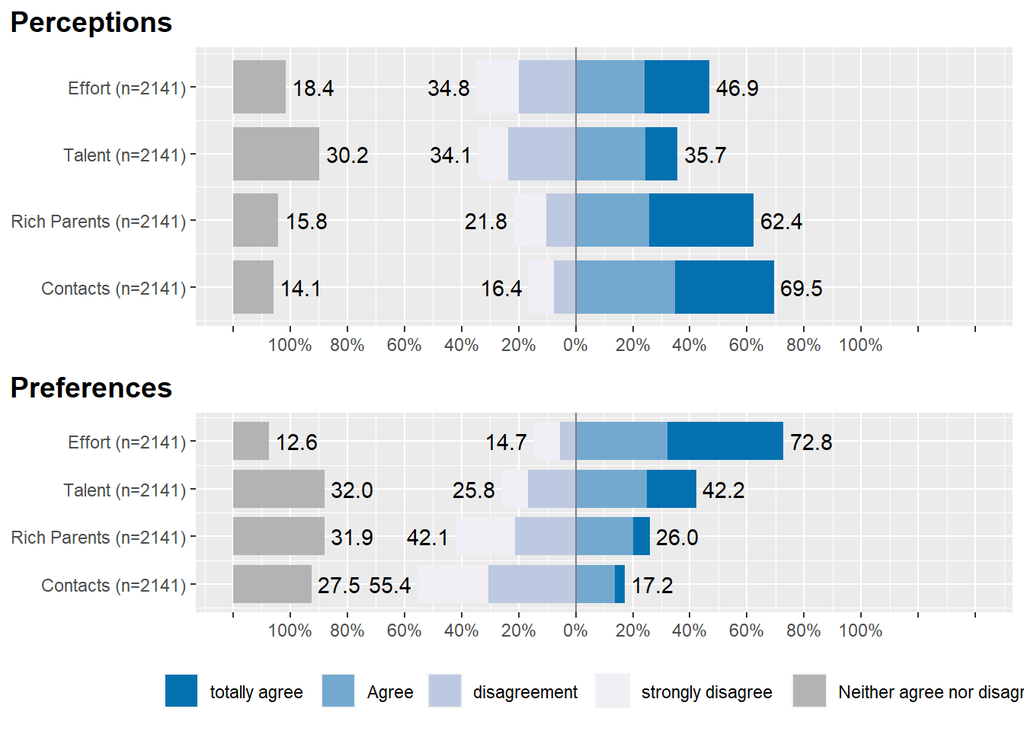

```r
library(ggplot2)
library(reshape2)
library(sjPlot)
library(dplyr)

#install.packages("cowplot")
library(cowplot)

dat_merit <- dat04 %>% select("a.Effort"=perc_effort,"a.Talent"=perc_talent, "a.Rich Parents"=perc_wpart, "a.Contacts"=perc_netw, "b.Effort"=pref_effort,"b.Talent"=pref_talent,"b.Rich Parents"=pref_wpart, "b.Contacts"=pref_netw)

dat_merit_2<- dat_merit %>% sjmisc::rec(rec="rev") %>% select("a.Effort"=a.Effort_r,"a.Talent"=a.Talent_r, "a.Rich Parents"="a.Rich Parents_r", "a.Contacts"=a.Contacts_r, "b.Effort"=b.Effort_r,"b.Talent"=b.Talent_r,"b.Rich Parents"="b.Rich Parents_r", "b.Contacts"=b.Contacts_r)


plotlikert<-plot_likert(dat_merit_2, c(1,1,1,1,2,2,2,2),
            groups.titles = c("Perceptions","Preferences"),
            geom.colors ="PuBu",
            geom.size = 0.8,
            axis.labels=c("Effort","Talent","Rich Parents","Contacts"),
            catcount = 4,
            cat.neutral = 3,
            grid.range  =  c ( 1.2 , 1.4 ),
            values  =  "sum.outside", reverse.colors = T)
plotlikert
```

```r
ggsave(plotlikert,filename = "output/images/plotlikert.png",device = "png",width = 25,height = 15,dpi = "retina",units = "cm")
```

```r
load(file = "input/data/original/issp2019CL.RData")
w01 <- sjlabelled::read_spss("input/data/original/Estudio_3_ola1.sav",verbose = F)
```

```r
GS<- c("CERRILLOS",
"CERRO NAVIA",
"CONCHALÍ",
"EL BOSQUE",
"ESTACIÓN CENTRAL",
"HUECHURABA",
"INDEPENDENCIA",
"LA CISTERNA",
"LA FLORIDA",
"LA GRANJA",
"LA PINTANA",
"LA REINA",
"LAS CONDES",
"LO BARNECHEA",
"LO ESPEJO",
"LO PRADO",
"MACUL",
"MAIPÚ",
"ÑUÑOA",
"PEDRO AGUIRRE CERDA",
"PEÑALOLEN",
"PROVIDENCIA",
"PUDAHUEL",
"PUENTE ALTO",
"QUILICURA",
"QUINTA NORMAL",
"RECOLETA",
"RENCA",
"SAN BERNARDO",
"SAN JOAQUÍN",
"SAN MIGUEL",
"SAN RAMÓN",
"SANTIAGO",
"VITACURA")

cl19$COMUNA <- toupper(as_character(cl19$COMUNA))

# cl19$DS_P1 # 1= hombre, 2= mujer
# cl19$DS_P2_EXACTA
# cl19$DS_P4

cep1 <- cl19 %>%
  select(COMUNA,DS_P1,DS_P2_EXACTA,DS_P4, FACTOR) %>%
  filter(COMUNA %in% GS)
```

```r
cep1$edad_cat<- as.numeric(cep1$DS_P2_EXACTA) # Edad
cep1$edad_cat[cep1$edad_cat %in%c(18:24)] <- 1   #"18 a 24"
cep1$edad_cat[cep1$edad_cat %in%c(25:34)] <- 2 # "25 a 34"
cep1$edad_cat[cep1$edad_cat %in%c(35:44)] <- 3 # "35 a 44"
cep1$edad_cat[cep1$edad_cat %in%c(45:54)] <- 4 # "45 a 54"
cep1$edad_cat[cep1$edad_cat >=  55]       <- 5 # "55 o más"

cep1$educ <- cep1$DS_P4 # Educación
cep1$educ <- as_numeric(cep1$educ)
cep1$educ <- as.numeric(cep1$educ)
cep1$educ[cep1$educ %in%c(88,99)] <- NA

cep1$educ <- recode(cep1$educ, "0" = "1" , "1"="1", "2" = "1", "3"="2","4"="2", "5"="3","6"="3", "7" = "3", "8"="4" , "9"="4"   )

cep1$sexo <- as.numeric(cep1$DS_P1) # 1= hombre, 2= mujer
```

```r
# Gender

cep1$Hombres<-ifelse(cep1$sexo==1,100,0)
cep1$Mujeres<-ifelse(cep1$sexo==2,100,0)
w01$Hombres<-ifelse(w01$sexo==1,100,0)
w01$Mujeres<-ifelse(w01$sexo==2,100,0)


cep1$ed_a<-ifelse(cep1$edad_cat==1,100,0)
cep1$ed_b<-ifelse(cep1$edad_cat==2,100,0)
cep1$ed_c<-ifelse(cep1$edad_cat==3,100,0)
cep1$ed_d<-ifelse(cep1$edad_cat==4,100,0)
cep1$ed_e<-ifelse(cep1$edad_cat==5,100,0)
w01$ed_a<-ifelse(w01$edad==1,100,0)
w01$ed_b<-ifelse(w01$edad==2,100,0)
w01$ed_c<-ifelse(w01$edad==3,100,0)
w01$ed_d<-ifelse(w01$edad==4,100,0)
w01$ed_e<-ifelse(w01$edad==5,100,0)



cep1$educ_a<-ifelse(cep1$educ==1,100,0)
cep1$educ_b<-ifelse(cep1$educ==2,100,0)
cep1$educ_c<-ifelse(cep1$educ==3,100,0)
cep1$educ_d<-ifelse(cep1$educ==4,100,0)
w01$educ_a<-ifelse(w01$educat==1,100,0)
w01$educ_b<-ifelse(w01$educat==2,100,0)
w01$educ_c<-ifelse(w01$educat==3,100,0)
w01$educ_d<-ifelse(w01$educat==4,100,0)


Men<-round(c(mean(w01$Hombres, na.rm = T), weighted.mean(cep1$Hombres,cep1$FACTOR, na.rm = T)),digits = 2)
Women<-round(c(mean(w01$Mujeres, na.rm = T), weighted.mean(cep1$Mujeres,cep1$FACTOR, na.rm = T)),digits = 2)

years.18.to.24<-round(c(mean(w01$ed_a, na.rm = T), weighted.mean(cep1$ed_a,cep1$FACTOR, na.rm = T)),digits = 2)
years.25.to.34<-round(c(mean(w01$ed_b, na.rm = T), weighted.mean(cep1$ed_b,cep1$FACTOR, na.rm = T)),digits = 2)
years.35.to.44<-round(c(mean(w01$ed_c, na.rm = T), weighted.mean(cep1$ed_c,cep1$FACTOR, na.rm = T)),digits = 2)
years.45.to.54<-round(c(mean(w01$ed_d, na.rm = T), weighted.mean(cep1$ed_d,cep1$FACTOR, na.rm = T)),digits = 2)
years.55.or.more<-round(c(mean(w01$ed_e, na.rm = T), weighted.mean(cep1$ed_e,cep1$FACTOR, na.rm = T)),digits = 2)



Primary <-round(c(mean(w01$educ_a, na.rm = T), weighted.mean(cep1$educ_a,cep1$FACTOR, na.rm = T)),digits = 2)
Secondary<-round(c(mean(w01$educ_b, na.rm = T), weighted.mean(cep1$educ_b,cep1$FACTOR, na.rm = T)),digits = 2)
Technique<-round(c(mean(w01$educ_c, na.rm = T), weighted.mean(cep1$educ_c,cep1$FACTOR, na.rm = T)),digits = 2)
University<-round(c(mean(w01$educ_d, na.rm = T), weighted.mean(cep1$educ_d,cep1$FACTOR, na.rm = T)),digits = 2)



sample_cep<- rbind("__Gender__",Men,Women,"__Age__",years.18.to.24,years.25.to.34,years.35.to.44,years.45.to.54,years.55.or.more, "__Education__", Primary, Secondary, Technique, University)


cnames <- c("Sample", "CEP")
knitr::kable(sample_cep, digits = 0, format = "markdown",col.names = cnames)
```

|  | Sample | CEP |
| --- | --- | --- |
|  | **Gender** | **Gender** |
| Men | 49.82 | 50.52 |
| Women | 50.18 | 49.48 |
|  | **Age** | **Age** |
| years.18.to.24 | 18.55 | 18.18 |
| years.25.to.34 | 18.86 | 17.48 |
| years.35.to.44 | 19.09 | 19.99 |
| years.45.to.54 | 17.96 | 19.24 |
| years.55.or.more | 25.54 | 25.12 |
|  | **Education** | **Education** |
| Primary | 2.93 | 15.88 |
| Secondary | 43.23 | 37.04 |
| Technique | 32.63 | 28.94 |
| University | 21.21 | 18.14 |

# 4 Anexo 2: Fiability

```r
load(file = "input/data/proc/dat01.RData")
load(file = "input/data/proc/dat02.RData")
load(file = "input/data/proc/dat03.RData")
load(file = "input/data/proc/dat04.RData")
```

```r
lav.mod.1 <- 'perc_merit =~ perc_effort+perc_talent
perc_nmerit=~perc_wpart +perc_netw
pref_merit =~ pref_effort+pref_talent
pref_nmerit=~pref_wpart +pref_netw'

cor01a<-polychoric(dat01)
cor02a<-polychoric(dat02)
cor03a<-polychoric(dat03)
cor04a <-polychoric(select(dat04,perc_effort,perc_talent,perc_wpart,perc_netw,pref_effort,pref_talent,pref_wpart,pref_netw))

#Omega for group
lav.jen.1<- cfa(lav.mod.1,sample.cov=cor01a$rho,sample.nobs=500,orthogonal=TRUE,std.lv=TRUE) # Total sample
lav.jen.2<- cfa(lav.mod.1,sample.cov=cor02a$rho,sample.nobs=500,orthogonal=TRUE,std.lv=TRUE) # Total sample
lav.jen.3<- cfa(lav.mod.1,sample.cov=cor03a$rho,sample.nobs=500,orthogonal=TRUE,std.lv=TRUE) # Total sample
lav.jen.4<- cfa(lav.mod.1,sample.cov=cor04a$rho,sample.nobs=500,orthogonal=TRUE,std.lv=TRUE) # Total sample


o1 <- omegaFromSem(lav.jen.1,cor04a$rho, plot = F)
o2<-omegaFromSem(lav.jen.2,cor04a$rho, plot = F)
o3<-omegaFromSem(lav.jen.3,cor04a$rho, plot = F)
o4<-omegaFromSem(lav.jen.4,cor04a$rho, plot = F)


Group_1 <- c(o1$omega.group$total)
Group_2 <- c(o2$omega.group$total)
Group_3 <- c(o3$omega.group$total)
Total_sample <- c(o4$omega.group$total)

Omega<- rbind(Group_1,Group_2,Group_3,Total_sample)

cnames <- c("Perception Meritocratic","Perception Non Meritocratic", "Preference Meritocratic","Preference Non Meritocratic")
knitr::kable(Omega, format = "markdown",digits = 2, col.names = cnames)
```

|  | Perception Meritocratic | Perception Non Meritocratic | Preference Meritocratic | Preference Non Meritocratic |
| --- | --- | --- | --- | --- |
| Group_1 | 0.86 | 0.79 | 0.71 | 0.81 |
| Group_2 | 0.83 | 0.73 | 0.70 | 0.71 |
| Group_3 | 0.80 | 0.77 | 0.59 | 0.75 |
| Total_sample | 0.83 | 0.76 | 0.67 | 0.76 |